# Leveraging GTFS data to assess transit supply

James Reynolds

2024-01-16

# Introduction

“If you can’t measure it, you can’t manage it” is often miss-attributed to Deming (1993), who was actually trying to make the opposite point (Berenson 2016). Regardless, service level indicators are an important part of researching, managing and seeking to improve transit operations (Fielding 1987; Ryus et al. 2003). A wide range of indicators already exist. Examples include: those in the Transit Capacity and Quality of Service Manual (TCQSM)(Kittleson & Associates et al. 2013), the Transit Score metric (Walk Score 2023) and many more.

Deming, W Edwards. 1993. “The New Economics for Industry, Government, Education.” MIT Press.

Berenson, Robert A. 2016. “If You Can’t Measure Performance, Can You Improve It?” *JAMA* 315 (7): 645–46.

Fielding, Gordon J. 1987. *Managing public transit strategically: a comprehensive approach to strengthening service and monitoring performance*. 1st ed. Jossey-Bass Public Administration Series. San Francisco: Jossey-Bass Publishers.

Ryus, Paul, M Connor, S Corbett, A Rodenstein, L Wargelin, L Ferreira, Y Nakanishi, and K Blume. 2003. “TCRP Report 88: A Guidebook for Developing a Transit Performance-Measurement System.” Transit Cooperative Research Program.

Kittleson & Associates, Parsons Brinckerhoff, KFH Group, Texas A&M Transportation Institute, and ARUP. 2013. *Transit Capacity and Quality of Service Manual, Third Edition*. Third Edition, TCRP Report 165. Washington DC: Transportation Research Board; Transportation Research Board. http://www.trb.org/Main/Blurbs/169437.aspx.

Walk Score. 2023. “Transit Score Methodology.” https://www.walkscore.com/transit-score-methodology.shtml.

Practitioners, researchers and advocates seeking to use such metrics may face two inter-related challenges: (1) there is the problem of calculating the metrics themselves for a specific location and service pattern; and (2) is the challenge of explaining the metrics, their meaning and importance to those who are not specialists in transit, such as to politicians or the general public. However, a relatively simple transit Supply Index (SI) has been previous developed (Currie and Senbergs 2007), This reduces service levels to a single score (like the Transit Score), but is open and can be independently calculated by anyone. It is obtained by calculating the number of transit arrivals at stops within an area of interest, with an adjustment made to account for the typical walk-access catchment for each stop. Hence, higher SI scores indicate areas with higher frequency and/or better coverage.

Of the examples above, the metrics in the TCQSM appear: difficult to calculate in practice, and difficult to explain because there are a multitude of indicators (although there is an entire guidebook explaining them, which might help somewhat); while, in contrast, Transit Scores can be obtained simply by typing an address into a website, but cannot be calculated independently and lack a detailed (and open source) description of the methodolgy / algorithm.

Currie, Graham, and Zed Senbergs. 2007. “Identifying spatial gaps in public transport provision for socially disadvantaged Australians: the Melbourne needs-gap study.” Australasian Transport Research Forum.

Unfortunately, the SI does not appear to have been widely used, perhaps in part because at the time it was first published timetable data was not typically publicly available in a standardized and machine-readable format. The scores reported in Currie and Senbergs (2007) has been calculated directly from a database of services provided by the transit authority in Melbourne, Australia. However, this database appears to have been in a format specific to Victoria and the agency itself, and so if SI scores for a different location were desired considerable work would be required to wrangle the data and calculate scores.

Public Transport Victoria (PTV)

Or perhaps even for Melbourne again, but at a different time given that the database format has likely changed and the Currie and Senbergs (2007) analysis algorithms are not readily available.

However, since the widespread adoption of the General Transit Feed Specification (GTFS), timetable data and tools for processing it are now much more widely available than they were in 2007. More than 10,000 agencies are now providing GTFS feeds(MobilityData undated), suggesting that the development of code to calculate SI scores directly from GTFS might allow it to be used more widely in research and practice.  
Previous work undertaken by Monash University’s Public Transport Research Group (PRTG), available on Github (Reynolds 2023), developed R functions to calculate SI scores from the Victorian PTV GTFS feed. However, the code was inefficient and untidy, and only allowed scores to be calculated for a whole day of transit service.

There are two forms: GTFS-static consisting of the timetable data (the scheduled services); and GTFS-realtime, which includes vehicle arrivals and departure times based on real-world position data. This paper and project uses only the GTFS-static (timetable) format.

MobilityData. undated. *General Transit Feed Specification (GTFS)*. {https://gtfs.org/}.

Reynolds, James. 2023. “Transit_supply_index_GTFS.” https://github.com/James-Reynolds/Transit_Supply_Index_GTFS.

To calculate SI scores for the Victorian GTFS feed would take the original code base approximately as long as it the service delivery itself took i.e. (SI scores fora whole week of transit service would take a whole week to compute!).

More recently, PTRG has commenced a project which requires SI scores by hour of the day. Unfortunately, the current code does not have this capability, and major changes will be needed to calculate stop arrivals on an hourly, rather than daily, basis. However, this also provides an opportunity to revise and improve the code so that it is more readily accessible, usable and understandable for others, and quicker.

This document reports the development of code to calculate SI scores from GTFS datasets as an R package (Reynolds 2024). Structuring the code as an R package provides various advantages as far as adhering to standardised conventions, accessibility and sharing, testing and so on (Wickham and Bryan 2023). More broadly, the motivation for this research is to better understand how GTFS data might be used to produce benchmarking metrics that can be calculated using open-source code. Such metrics might then be able to be used to assess proposed network changes or other analyses without the need for specialist software or bespoke calculation. A related objective is to increase the availability of metrics that are relatively easy to understand and use when making decisions about or advocating for changes to existing services, including for those who may not be technical specialists in transit planning and scheduling.

Reynolds, James. 2024. “Gtfssupplyindex.” https://github.com/James-Reynolds/gtfssupplyindex.

Rather than as scripts within a R Markdown file, as for the original Transit_Supply_Index_GTFS efforts

Wickham, Hadley, and Jennifer Bryan. 2023. *R Packages*. " O’Reilly Media, Inc.". https://r-pkgs.org/.

More formally, the (null) hypothesis tested in this research is that the Supply Index cannot be calculated directly from a GTFS feed.

# Research context

Even a brief search shows that there is a very large number of metrics available for benchmarking transit services. Examples include: (1) those in the Transit Cooperative Research Program (TCRP) Report 88, which is an extensive guidebook on developing a performance-measurement system (Ryus et al. 2003); (2) online databases provided by the Florida Transit Information System (FTIS) (Florida Transit Information System 2018) and International Association of Public Transport (UITP) (2015); (3) those used in the extensive annual benchmarking programme undertaken yearly by the Transport Strategy Centre, which includes over 100 transit providers around the world (Imperial College London undated); and (4) a recently developed methodology to calculate ‘blank spots’ within an area, being those places beyond 400/800 metre walking distances to/from bus and tram stops/train stations (Alamri et al. 2023).

Ryus, Paul, M Connor, S Corbett, A Rodenstein, L Wargelin, L Ferreira, Y Nakanishi, and K Blume. 2003. “TCRP Report 88: A Guidebook for Developing a Transit Performance-Measurement System.” Transit Cooperative Research Program.

Florida Transit Information System. 2018. “Urban Integrated National Transit Database.” http://www.ftis.org/urban_intd.aspx.

International Association of Public Transport (UITP). 2015. “Mobility in Cities Database 2015.” Brussels, Belgium. uitp.org/publications/mobility-in-cities-database/.

Imperial College London. undated. “Transport Strategy Centre (TSC); Applied Research.” undated. https://www.imperial.ac.uk/transport-engineering/transport-strategy-centre/applied-research/.

Alamri, Sultan, Kiki Adhinugraha, Nasser Allheeib, and David Taniar. 2023. “GIS Analysis of Adequate Accessibility to Public Transportation in Metropolitan Areas.” *ISPRS International Journal of Geo-Information* 12 (5): 180.

The Fielding Triangle (Fielding 1987) provides a framework for understanding how such metrics combine service inputs, service outputs and service consumption to describe cost efficiency, cost effectiveness or service effectiveness. At a larger scale, Litman (2003) and Litman (2016) discuss some of the traffic, mobility, accessibility, social equity, strategic planning and other rational decision-making frames that might underlie such transit metrics, while Reynolds et al. (2017) extends this into models of how institutionalism, incrementalism and other public policy models might apply to decision-making processes. Further examples include: (1) Guzman, Oviedo, and Rivera (2017), who develop a measure of accessibility in the context of policy development and social equity for Latin American Bus Rapid Transit (BRT) based networks; and (2) the street space allocation metrics based around 10 ethical principles introduced by Creutzig et al. (2020).

Fielding, Gordon J. 1987. *Managing public transit strategically: a comprehensive approach to strengthening service and monitoring performance*. 1st ed. Jossey-Bass Public Administration Series. San Francisco: Jossey-Bass Publishers.

Litman, Todd. 2003. “Measuring Transportation: Traffic, Mobility and Accessibility.” 10. Vol. 73. Institute of Transportation Engineers. ITE Journal. Washington, D.C.: Institute of Transportation Engineers.

Litman, Todd. 2016. “When Are Bus Lanes Warranted? Considering Economic Efficiency, Social Equity and Strategic Planning Goals.” Victoria Transport Policy Institute. http://www.vtpi.org/blw.pdf.

Reynolds, James, Graham Currie, Geoff Rose, and Alistair Cumming. 2017. “Moving Beyond Techno-Rationalism: New Models of Transit Priority Implementation.” In *Australasian Transport Research Forum 2017*. Auckland, New Zealand.

Guzman, Luis A., Daniel Oviedo, and Carlos Rivera. 2017. “Assessing Equity in Transport Accessibility to Work and Study: The Bogotá Region.” *Journal of Transport Geography* 58: 236–46.

Creutzig, Felix, Aneeque Javaid, Zakia Soomauroo, Steffen Lohrey, Nikola Milojevic-Dupont, Anjali Ramakrishnan, Mahendra Sethi, et al. 2020. “Fair Street Space Allocation: Ethical Principles and Empirical Insights.” *Transport Reviews* 40 (6): 711–33. https://doi.org/10.1080/01441647.2020.1762795.

However, many of these metrics appear difficult to calculate, complex to explain or understand, and likely not well suited to communication with those who are not transit planners or engineers, or otherwise technical specialists. Where pre-calculated metrics are immediately available it may not be possible for practitioners, researchers or advocates to independently generate metrics for proposed system changes or to even know exactly how scores for the existing services levels are calculated. For example, Transit Scores for locations with a published GTFS feed are readily available on a website, eliminating the need for any calculations. The meaning of these Transit Scores appears easy to explain, as the highest possible score of 100 represents what might be experienced in the centre of New York(Walk Score 2023)]. However, the Transit Score algorithm is patented and effectively a black box. It is not possible to calculate scores independently or understand how the metric might change with alteration to the transit system or services, or the surrounding environment. Transit Score, therefore, fails the first of the aforementioned challenges, as practitioners, researchers and advocates can only use those scores provided by Walk Score (2023) While the metric is simple to explain, as the closer to 100, the better, because it is based on a patented algorithm it may not be easy to understand or explain the connection between real-world conditions and the Transit Score, or what might need to be done to improve the score and service levels. Nor does it appear to be possible for Transit Scores to be generated for proposed changes to networks.

Walk Score. 2023. “Transit Score Methodology.” https://www.walkscore.com/transit-score-methodology.shtml.

Walk Score. 2023. “Transit Score Methodology.” https://www.walkscore.com/transit-score-methodology.shtml.

Another example is the TCQSM, which specifies Levels of Service (LOS) between A and F across a range of factors. This scoring scheme appears relatively simple to explain, and the detail within Kittleson & Associates et al. (2013) provides a resource for anyone wanting to better understand what the scores mean. However, calculation of many of TCQSM metrics may need specialised software and datasets and it might be challenging to explain the detail of these measures or how to improve them to non-technical decision-makers, stakeholders or others involved in transit management or advocacy.

Including service span, frequency, speed, the proportion of the population serviced, competitiveness of travel times to car-based travel, and many more.

A is good and F is bad. Also this scoring system matches the A to F LOS scoring used in many traffic capacity analysis software and manuals.

Kittleson & Associates, Parsons Brinckerhoff, KFH Group, Texas A&M Transportation Institute, and ARUP. 2013. *Transit Capacity and Quality of Service Manual, Third Edition*. Third Edition, TCRP Report 165. Washington DC: Transportation Research Board; Transportation Research Board. http://www.trb.org/Main/Blurbs/169437.aspx.

For example, the Service Coverage Area metric in the TCQSM (pp. 5-8 to 5-21) may require GIS or other analysis, on top of accurate data about population densities, stop locations and service schedules.

The introduction of the General Transit Feed Specification (GTFS) and widespread release of schedule data in this format, however, has helped towards making transit metrics more broadly available and useable. GTFS is an open, text-based format that was developed originally to allow transit information to be included in the Google Maps navigation platform (MobilityData undated). The data structure is shown in the below figure.

MobilityData. undated. *General Transit Feed Specification (GTFS)*. {https://gtfs.org/}.

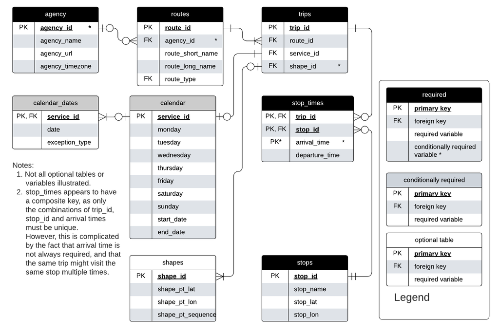

GTFS entity relationship diagram. Source: adapted by author from Alamri et al (2023) and the GTFS Schedule Reference (16/11/2023 revision).

In the Entity Relationship Diargram (ERD) shown above, each box represents a database table in the GTFS, with table rows indicating the variables (columns) included in each. Relationships between the tables are indicated by the connecting lines, and Primary Key (PK) and Foreign Key (FK) designations. `Crow’s feet’ indicate the relationships between each table.

For example, each record in the ‘stops’ table includes a value for stop_id, stop_name, stop_lat and stop_lon.

For example, stop_id also appears in the ‘stop_times’ table as a Primary Key and Foreign Key.

See https://i.stack.imgur.com/fxaAq.png for guide to the symbols. But, for example, the stops table is required, with the stop_id field providing a unique (primary) key for every stop. Within the stop_times table (which is also required) the stop_id field is a foreign key. Each unique stop_id can appear many times in the stop_times table, but must appear only once in the stops table. In the stop_times table each combination of trip_id, stop_id and arrival time must be unique (But, see note 2!) meaning that these fields represent a composite key.

GTFS now provides a mechanism for including individual transit systems in many online products and analyseses, including the Transit Score metric itself. Wong (2013) provides another example of what can be done with GTFS data, having developed code to calculate of some of the TCQSM metrics. While the Wong (2013) open-source code is readily available this is now 11 years old and does not appear to be currently maintained. Future research may involve reviewing this code and using it to analyse modern GTFS feeds. However, in this paper the aim is more modest, being to use GTFS data to calculate Currie and Senbergs’ (2007) SI.

Wong, James. 2013. “Leveraging the General Transit Feed Specification for Efficient Transit Analysis.” *Transportation Research Record* 1 (2338): 11–19. https://doi.org/10.3141/2338-02.

Daily average headways, route length and stop numbers for 50 transit operators.

Wong, James. 2013. “Leveraging the General Transit Feed Specification for Efficient Transit Analysis.” *Transportation Research Record* 1 (2338): 11–19. https://doi.org/10.3141/2338-02.

https://github.com/jcwong86/GTFS_Explore_Tool

## The Suppy Index

$$\begin{equation}
SI_{area, time} = \sum{\frac{Area_{Bn}}{Area_{area}}*SL_{n, time}}
\end{equation}$$

The Supply Index (SI) equation is shown in the margin figure, in which: (1) $SI_{area, time}$ is the Supply Index for the area of interest and a given period of time; (2) $Area_{Bn}$ is the buffer area for each stop (n) within the area of interest. In Currie and Senbergs (2007) this was based on a radius of 400 metres for bus and tram stops, and 800 metres for railway stations; (3) $Area_{area}$ is the area of the area of interest; and (4) $SL_{n,time}$ is the number of transit arrivals for each stop for a given time period.

Minor adjustments have been made to generalise the equation, as Currie and Senbergs (2007) focus was the context of Melbourne’s Census Collection Districts (CCD) and calculations based on a week of transit service. CCDs predate the introduction of Statistical Areas 1, 2, 3, and 4 (SA1, SA2, SA3, SA4), and other geographical divisions currently used by the Australian Bureau of Statistics (ABS), which may be more familiar to readers.

An advantage of the SI is that it is a relatively simple number to calculate, understand and explain. It describes the number of transit arrivals at stops within an area of interest and time frame, multiplied by a factor accounting for the proportion of the area of interest that is within typical walking distance of each stop. Hence, more services, more stops and higher frequencies would all increase the SI score. The SI does not incorporate service span, speed or other elements of a transit service. These may be important to passenger experience, but might add considerable complexity. Simplicity is also helped by the way that the Index is additive, in that $SI_{area, time}$ scores can be aggregated to calculate an overall score across multiple time periods or for a region encompassing multiple areas of interest.

# Methodology

R (R Core Team 2023), a widely used and readily available statistical programming language, was adopted for code development. The package development setup and workflow described by Wickham and Bryan (2023) was adopted in this study.

R Core Team. 2023. *R: A Language and Environment for Statistical Computing*. Vienna, Austria: R Foundation for Statistical Computing. https://www.R-project.org/.

Wickham, Hadley, and Jennifer Bryan. 2023. *R Packages*. " O’Reilly Media, Inc.". https://r-pkgs.org/.

Various existing packages were relied upon including: the sf package (Pebesma 2023) for geospatial analysis; the tidyverse (Wickham et al. 2019); gtfstools (Daniel Herszenhut et al. 2022); and tidytransit (Poletti et al. 2023). Some code was adapted from the tidytransit, gtfstools and other package’s examples, vignettes and other documentation. Tidytransit is licensed under GPL-2 | GPL-3, while gtfstools is lincensed under the more permissive MIT license. For simplicity, the gtfssupplyindex package developed here is licensed under GPL-3 so as to match tidytransit.

Pebesma, Edzer. 2023. *Sf: Simple Features for r*. https://r-spatial.github.io/sf/.

Wickham, Hadley, Mara Averick, Jennifer Bryan, Winston Chang, Lucy D’Agostino McGowan, Romain François, Garrett Grolemund, et al. 2019. “Welcome to the tidyverse.” *Journal of Open Source Software* 4 (43): 1686. https://doi.org/10.21105/joss.01686.

Herszenhut, Daniel, Rafael H. M. Pereira, Pedro R. Andrade, and Joao Bazzo. 2022. *Gtfstools: General Transit Feed Specification (GTFS) Editing and Analysing Tools*. https://ipeagit.github.io/gtfstools/.

Poletti, Flavio, Daniel Herszenhut, Mark Padgham, Tom Buckley, and Danton Noriega-Goodwin. 2023. *Tidytransit: Read, Validate, Analyze, and Map GTFS Feeds*. https://github.com/r-transit/tidytransit.

## Cases

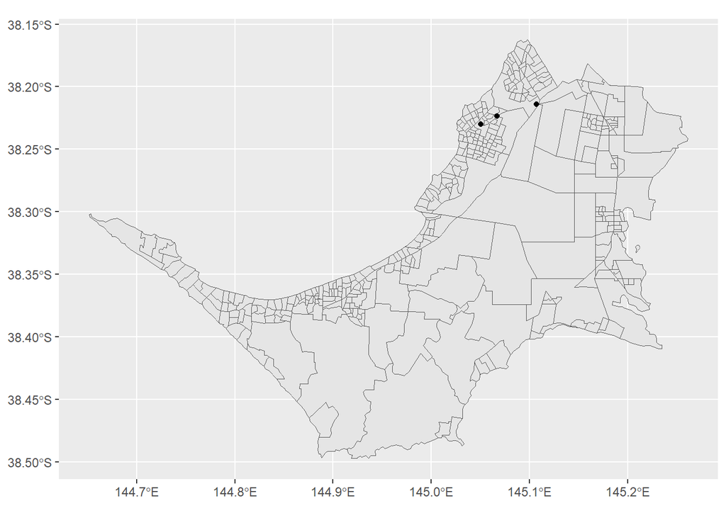

Mornington Penninsula SA1 zones and location of Mornington Tourist Rail stops.

Code development was undertaken using a number of cases for testing purposes, being: the Mornington Penninsula Tourist Railway, the New York subway, and Melbourne.

The Morning Penninsula Tourist Railway runs on Sundays and Wednesdays between Moorooduc and Mornington, with an intermediate stop at Tanti Park. A GTFS feed from 2018 was selected. ABS data was also used, primarily through the strayr and absmapsdata packages (Mackey et al. 2023). The Mornington Peninsular SA3 zone and the SA1 zones contained within were adopted as the areas_of_interest.

https://transitfeeds.com/p/mornington-railway/806/latest/stops

Mackey, Will, Matt Johnson, David Diviny, Matt Cowgill, Bryce Roney, William Lai, and Benjamin Wee. 2023. “Strayr.” https://runapp-aus.github.io/strayr/.

Tidytransit includes a sample GTFS feed from New York’s MTA (including the subway!), and so this was used for code tests were appropriate.

Larger scale testing was performed using the Victorian GTFS feed, published by Public Transport Victoria (PTV), sourced via Transit Mobility Data, (2023) for historical feeds. Again, ABS data was used for the areas_of_interest.

Transit Mobility Data,. 2023. “PTV GTFS - OpenMobilityData.” 2023. https://transitfeeds.com/p/ptv/497.

# Results

## Code structure and output

Developed code is available and documented on github (Reynolds 2024). The structure and functions used to generate each table are shown in the below Entity Relationship Diagram (ERD).

Reynolds, James. 2024. “Gtfssupplyindex.” https://github.com/James-Reynolds/gtfssupplyindex.

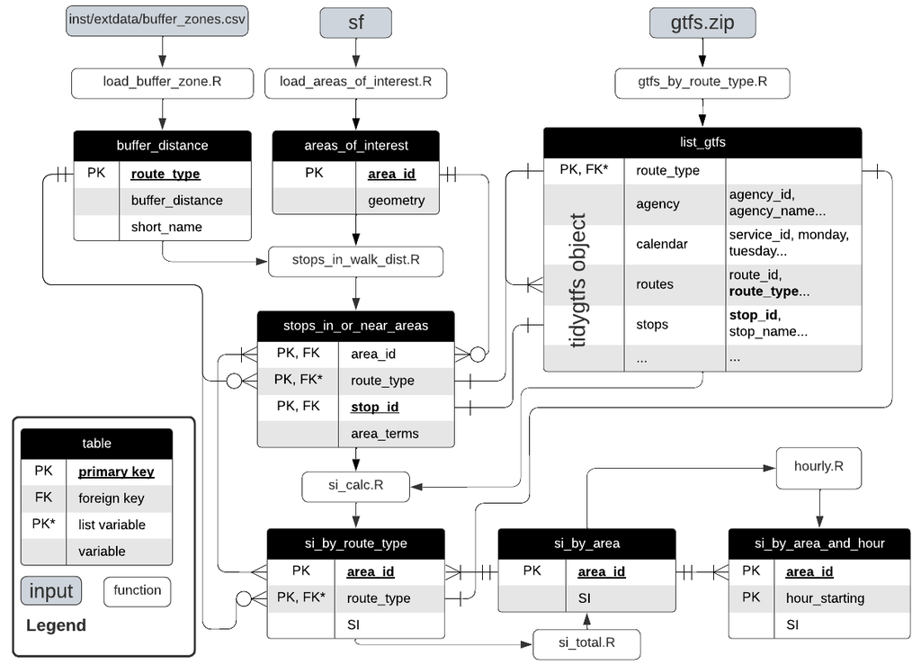

Entity Relationship Diagram (ERD) showing the data structure and functions

The package takes input from three files:

- a gtfs feed (gtfs.zip)
- a sf object describing the geometry of the areas for which the SI is to be calculated
- a csv file defining the buffer zone distances (in metres) for each route_type - a version of this file is included in the package.

It outputs the si_by_area_and_hour table (bottom right), which reports the SI score for each hour of the day across dates specified by the user.

| area_id | 10 | 11 | 12 | 13 | 14 | 15 |
| --- | --- | --- | --- | --- | --- | --- |
| 214021381 | 0.0000672 | 0.0522962 | 0.0523635 | 0.0000672 | 0.0522962 | 0.0523635 |
| 214021385 | 0.0000000 | 0.0067970 | 0.0067970 | 0.0000000 | 0.0067970 | 0.0067970 |
| 214021591 | 0.2436873 | 0.1366432 | 0.3803305 | 0.1366432 | 0.2436873 | 0.3803305 |
| 214021592 | 0.0684965 | 0.0000000 | 0.0684965 | 0.0000000 | 0.0684965 | 0.0684965 |

## Functions

This section briefly describes each of the functions shown in the above ERD, and how these facilitate the calculation of the SI scores.

### gtfs_by_route_type function

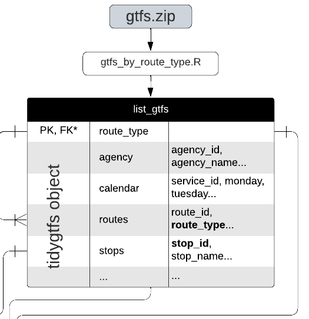

Entity Relationship Diagram (ERD) excerpt, gtfs_by_route_type function

GTFS data is first loaded, with the gtfs_by_route_type function splitting this into a list (by route_type) of tidygtfs objects. This is achieved using the filter_by_route_type function from the gtfstools package (Danile Herszenhut et al. undated).

Herszenhut, Danile, Rafael H. M. Pereira, Pedro R. Andrade, and Joao Bazzo. undated. *Gtfstools; Filter GTFS Object by Route Type (Transport Mode)*. https://ipeagit.github.io/gtfstools/reference/filter_by_route_type.html.

```r
#load the revised mornington GTFS data
list_gtfs = gtfssupplyindex:::gtfs_by_route_type(system.file(
  "extdata/mornington180109",
  "gtfs.zip",
  package = "gtfssupplyindex",
  mustWork = TRUE))

names(list_gtfs) %>% kable(caption = "tidygtfs objects within list_gtfs")
```

tidygtfs objects within list_gtfs

| x |
| --- |
| rail |

```r
names(list_gtfs[[1]]) %>% kable(caption = "tidygtfs structure of first element of list_gtfs")
```

tidygtfs structure of first element of list_gtfs

| x |
| --- |
| agency |
| calendar |
| calendar_dates |
| fare_attributes |
| fare_rules |
| feed_info |
| routes |
| shapes |
| stop_times |
| stops |
| trips |
| . |

### load_areas_of_interest function

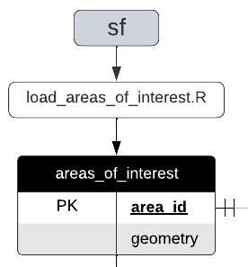

Entity Relationship Diagram (ERD) excerpt, load_areas_of_interest function

Geographical data about the areas of interest are first loaded by the load_areas_of_interest.R function into an sf object using the Pebesma (2023) package. The resultant areas_of_interest table contains each area_id and its associated geometry.

Pebesma, Edzer. 2023. *Sf: Simple Features for r*. https://r-spatial.github.io/sf/.

First 6 entries in areas_of_interest table

| area_id | geometry |
| --- | --- |
| 21402137701 | MULTIPOLYGON (((144.9617 -3… |
| 21402137702 | MULTIPOLYGON (((144.9916 -3… |
| 21402137703 | MULTIPOLYGON (((144.9923 -3… |
| 21402137704 | MULTIPOLYGON (((144.9878 -3… |
| 21402137705 | MULTIPOLYGON (((145.0015 -3… |
| 21402137706 | MULTIPOLYGON (((145.0088 -3… |

Data about buffer zones, specifically the walking distance threshold assigned to each route_type (mode) is then loaded, again through a function (load_buffer_zone.R). The package includes this information in a csv file, in which it is assumed that the buffer zone is definied in metres.

First six entries in buffer_distance definitions

| route_type | buffer_distance | short_name |
| --- | --- | --- |
| 0 | 400 | lrt |
| 1 | 800 | subway |
| 2 | 800 | rail |
| 3 | 400 | bus |
| 4 | 800 | ferry |
| 5 | 400 | cable_tram |

### stops_in_walk_dist function

Entity Relationship Diagram (ERD) excerpt, stops_in_walk_dist function

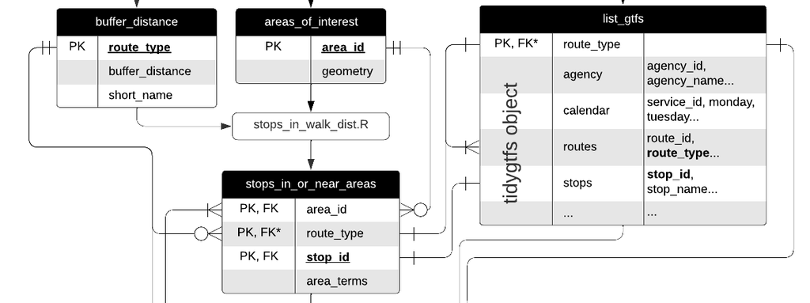

The stops_in_walk_dist function then generates a list (by route_type) in which each element is a datea table describing which stops are within walking distance of which areas of interest. Each table entry includes a stop_id, an area_id that is within the buffer_distance threshold of that stop, and the corresponding area related terms in the SI calculation.

This is the $Area_{Bn} / Area_{Area}$ bit

‘Rail’ element of the stops_in_or_near_areas list for the Mornington Pennisula datasets, first six entries

| stop_id | area_id | area_terms |
| --- | --- | --- |
| 1388695887 | 21402159101 | 0.7999912 |
| 1388695887 | 21402159102 | 0.0168220 |
| 1388695887 | 21402159105 | 0.6779951 |
| 1388695887 | 21402159107 | 0.6453927 |
| 1388695887 | 21402159111 | 0.2011127 |
| 1388695887 | 21402159113 | 0.1081424 |

The variables passed to the stop_in_or_near_areas function are list_gtfs, the areas_of_interest table, the buffer_distance table, and an EPSG_for_transform variable. This last variable is the Coordinate Reference System (CRS) value relevant to the geographic location. It is used to project the latitude and longitude values included in the GTFS data and area_of_interest data into metres, in this case relating to the GDA94 / MGA zone 55 relevant to Australia.

The list of tidygtfs objects ouput by the gtfs_by_route_type function

Which is the output of the load_areas_of_interest function

Output by the load_buffer_zones function

https://epsg.io/28355

The stops_in_walk_dist function is complicated by the need to have different buffer distances for each route_type, and to only include those parts of the walking catchment that are within each area of interest. It is structured as follows:

1. The first part of the stops_in_walk_dist function looks up the buffer_distance_length specific to each route_type in the list (by route_type) of tidygtfs objects. This value is appended to each tidygtfs object as an additional element (named buffer_distance).
2. Next the areas_of interest are transformed from latitude and longitude into metres, and the area is calculated.
3. The stops_in_walking_distance function then applies a sub-function, stops_in_walk_dist_one_route, to the list_gtfs (list of tidygtfs objects), in which:
4. A list of stops is extracted from the tidygtfs, using the stops_as_sf function from Poletti et al. (2023).

   Poletti, Flavio, Daniel Herszenhut, Mark Padgham, Tom Buckley, and Danton Noriega-Goodwin. 2023. *Tidytransit: Read, Validate, Analyze, and Map GTFS Feeds*. https://github.com/r-transit/tidytransit.
5. Circles are then drawn around each stop, with the radius equal to the buffer distance. Intersecting these circles with the areas_of_interest then outputs an sf showing the catchment of each stop within each area of interest
6. Finally, the $area_{Bn}$ terms are calculated for each combination of stop_id and area_id,

The stops_in_walk_dist function includes a mode with output printed at each intermediate step (verbose = TRUE). The below shows the Morington Penninsula railway calculations again (as per the previous table), but run with verbose = TRUE so that intermediate steps are printed.

```r
stops_in_or_near_areas <- gtfssupplyindex:::stops_in_walk_dist(
  list_gtfs = list_gtfs,
  areas_of_interest = areas_of_interest,
  EPSG_for_transform = 28355,
  verbose = TRUE
)
```

Step 5, circles around each stop, showing the intersections with the areas_of_interest, all stops

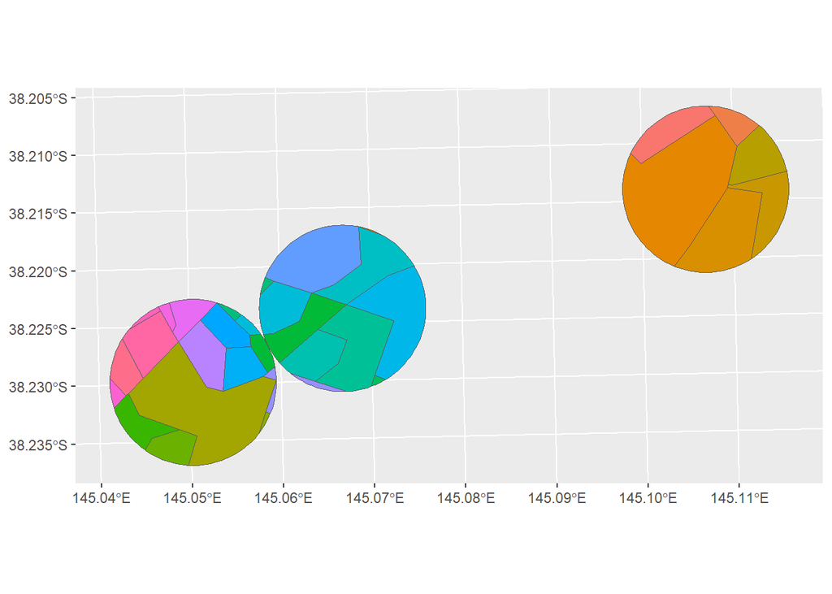

as above, but from each stop individually

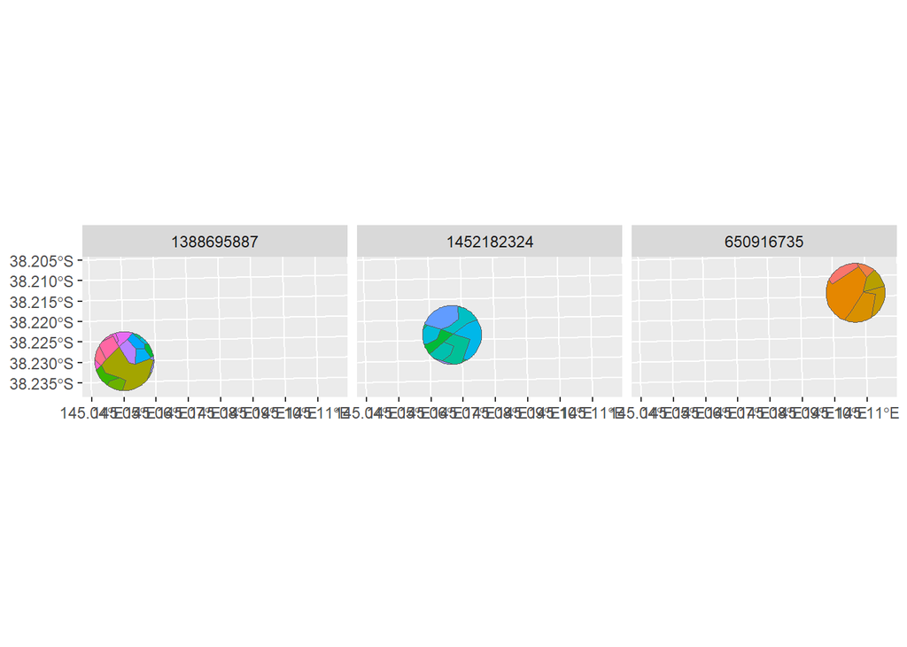

### Calculating stop arrivals and the SI, SI_total and hourly

Entity Relationship Diagram (ERD) excerpt, si_calc, si_total and hourly functions

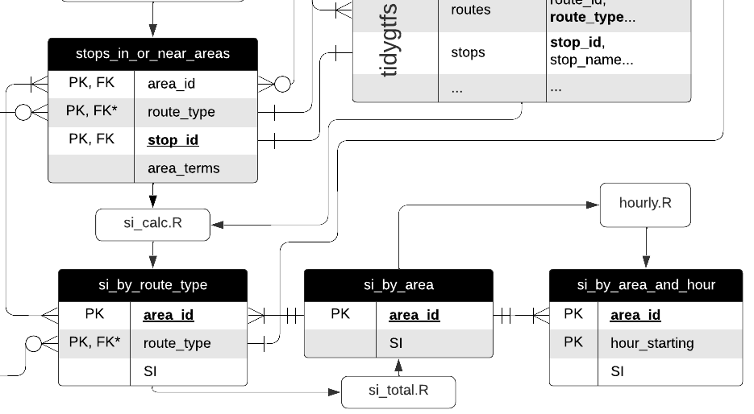

The si_calc.R function takes the stops_in_or_near_areas list (by route_type) of dataframes and the list_gtfs list (by route_type) of tidygtfs objects and calculates the si_by_route_type

Which, again, is a list (by route_type) of dataframes, each containing a record for each area_id and combination of date, start_time and end_time specified by the user, and the corresponding (calculated) SI value.

The tidytransit package includes an article about generating a departure timetable from a gtfs dataset (Poletti undated). Code from that article was adapted from this example to create functions to calculate the number of departures and arrivals from (a vector of) stop_ids within a given time period. These functions are included in the package and called by the si_calc function. Output from the arrivals function is shown in the bellow table.

Poletti, Flavio. undated. *Tidytransit: Generate a Departure Timetable*. https://r-transit.github.io/tidytransit/articles/timetable.html.

See departures_and_arrivals.R

Although this is not shown on the ERD

```r
stop_ids <- list_gtfs[[1]]$stops %>%
 dplyr::select(stop_id)

arrivals_by_stop_id <- gtfssupplyindex::arrivals(
 gtfs = list_gtfs[[1]],
 stop_ids = stop_ids,
 date_ymd = "2018-12-30",
 start_hms = lubridate::hms("10:30:00"),
 end_hms = lubridate::hms("16:00:00")
)

arrivals_by_stop_id %>% kable(caption = "Arrivals at each stop for Sunday December 30th 2018, Mornington Peninsula tourist railway.")
```

Arrivals at each stop for Sunday December 30th 2018, Mornington Peninsula tourist railway.

| stop_id | arrivals |
| --- | --- |
| 1388695887 | 4 |
| 1452182324 | 8 |
| 650916735 | 4 |

This matches the number of trips shown in the Mornington Railway GTFS feed, being 4 in each direction.

https://transitfeeds.com/p/mornington-railway/806/latest/stop/1388695887/20181230

Arrivals at Mornington Station (stop_id 1388695887) for 30/12/2018

[figure not shown]

All the inputs to calculate the si are now available. Hence, the SI.calc function can be run, resulting in the si_by_route_type list (by route_type) of tables showing the area_id corresponding SI values

SI values for Mornington Penninsula Railway services on 30/12/2018 (full day)

| area_id | SI |
| --- | --- |
| 214021381 | 0.2094539 |
| 214021385 | 0.0271880 |
| 214021591 | 1.5213219 |
| 214021592 | 0.2739859 |

The si_total function aggregates the si_by_route_type tables so that values are no longer separated by mode. Although in the case of the Mornington Penninsula Railway there is only one route_type.

Finally, the hourly function runs the si_calc and si_total functions for every hour in a single day. It outputs a table showing the SI scores for each area for each hour of the day. The below table shows this output, together with row and column totals.

Across the service span

| area_id | 10 | 11 | 12 | 13 | 14 | 15 | Total |
| --- | --- | --- | --- | --- | --- | --- | --- |
| 214021381 | 0.0000672 | 0.0522962 | 0.0523635 | 0.0000672 | 0.0522962 | 0.0523635 | 0.2094539 |
| 214021385 | 0.0000000 | 0.0067970 | 0.0067970 | 0.0000000 | 0.0067970 | 0.0067970 | 0.0271880 |
| 214021591 | 0.2436873 | 0.1366432 | 0.3803305 | 0.1366432 | 0.2436873 | 0.3803305 | 1.5213219 |
| 214021592 | 0.0684965 | 0.0000000 | 0.0684965 | 0.0000000 | 0.0684965 | 0.0684965 | 0.2739859 |
| Total | 0.3122510 | 0.1957364 | 0.5079874 | 0.1367104 | 0.3712770 | 0.5079874 | 2.0319496 |

## Testing the package on the Mornington Peninsula Tourist Railway and (just) the Mornington Peninsula SA3 zone

In the previous sections the code structure, output and functions were described. Results the Mornington Peninsula Tourist Railway’s GTFS data set and the SA1 zones were also presented as an example case.

In this section the same GTFS data is used, but with the areas of interest set instead to be the entire Mornington Peninsula SA3 area. As all three of the Mornington Peninsula Raiway’s stops are located within this SA3 zone the calculation of the SI scores by hand is relatively simple, and is used here as a check on the results.

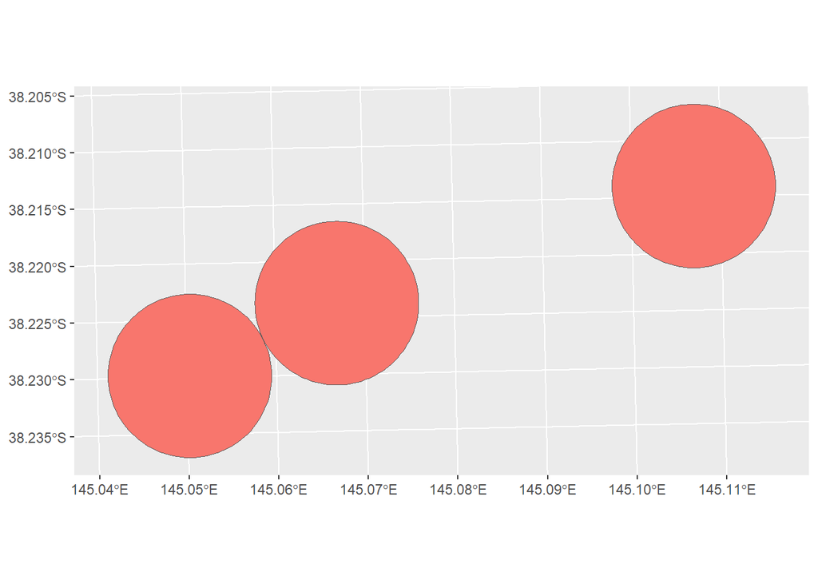

Mornington Penninsula Tourist Railway catchments within the Mornington Penninsula SA3 zone

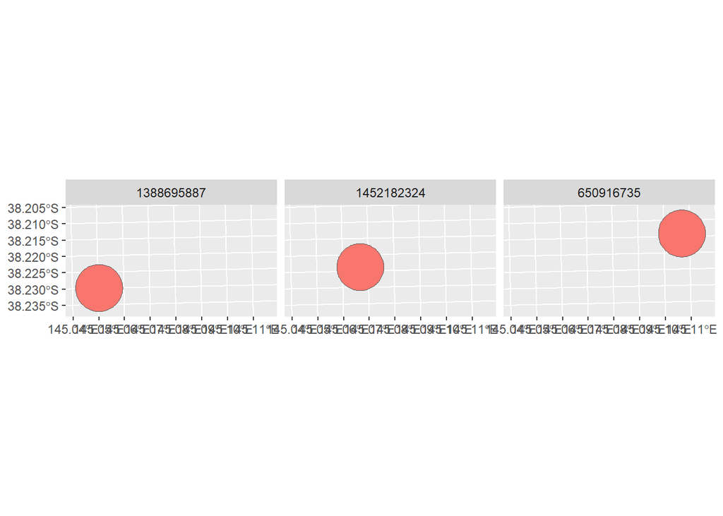

Mornington Penninsula Tourist Railway catchments within the Mornington Penninsula SA3 zone

```r
#load the revised mornington GTFS data
list_gtfs = gtfssupplyindex:::gtfs_by_route_type(system.file(
  "extdata/mornington180109",
  "gtfs.zip",
  package = "gtfssupplyindex",
  mustWork = TRUE))

areas_of_interest <- load_areas_of_interest(absmapsdata::sa32021 %>% filter(sa3_name_2021 == "Mornington Peninsula") %>% select(sa3_code_2021),  area_id_field = "sa3_code_2021")

buffer_distance <- gtfssupplyindex:::load_buffer_zones()

stops_in_or_near_areas <- gtfssupplyindex:::stops_in_walk_dist(
  list_gtfs = list_gtfs,
  areas_of_interest = areas_of_interest,
  EPSG_for_transform = 28355,
  verbose = TRUE
)
```

```r
kable(stops_in_or_near_areas, caption = "Catchment of each stop within Mornington Penninsula SA3 zone")
```

Catchment of each stop within Mornington Penninsula SA3 zone

| stop_id | area_id | area_terms |
| --- | --- | --- |
| 1388695887 | 21402 | 0.0027748 |
| 1452182324 | 21402 | 0.0027748 |
| 650916735 | 21402 | 0.0027748 |

As shown in the figures and above tables, the area terms for each of the combinations of stop_id and area_id are ~ 0.0028. All of the catchment areas of each stop fall within the single area_of_interest, being the Mornington Penninsula SA3.

area_id 21402

Checking the area terms calculation is relatively trivial for this case, as the ABS maps data comes with an areasqkm_2021 field. Dividing the catchment area of the stop by the area of the area_of_interest as follows:

$Area_{Bn} = \pi0.8^2$

$Area_{area} = 724.19$

$$\begin{equation}
SI_{area, time} = \sum{\frac{Area_{Bn}}{Area_{area}}*SL_{n, time}}
\end{equation}$$

```r
absmapsdata::sa32021 %>% filter(sa3_name_2021 == "Mornington Peninsula")
```

```
## Simple feature collection with 1 feature and 11 fields
## Geometry type: MULTIPOLYGON
## Dimension:     XY
## Bounding box:  xmin: 144.6514 ymin: -38.49884 xmax: 145.2615 ymax: -38.16239
## Geodetic CRS:  WGS 84
##   sa3_code_2021        sa3_name_2021 sa4_code_2021        sa4_name_2021
## 1         21402 Mornington Peninsula           214 Mornington Peninsula
##   gcc_code_2021     gcc_name_2021 state_code_2021 state_name_2021 areasqkm_2021
## 1         2GMEL Greater Melbourne               2        Victoria      724.1681
##    cent_lat cent_long                       geometry
## 1 -38.34165  145.0355 MULTIPOLYGON (((145.2129 -3...
```

```r
pi * .8^2 /
  (as.numeric(
    absmapsdata::sa32021 %>%
      st_drop_geometry() %>%
      filter(
        sa3_name_2021 == "Mornington Peninsula") %>%
      select(areasqkm_2021)
  ))
```

```
## [1] 0.002776454
```

The calculated area_terms match, albeit with what appears to be some minor rounding errors. This appears to related to the ABS reported square_km (724.1681) being slightly different from the m2 reported by the st_area function used within the package (724,272,059). Likely this is related to the ABS having a slightly different methodology for calculating the area, and the error is approximately 0.015%.

Completing the calculations by hand gives:

stop_id 1388695887:

- $Area_{Bn} = \pi0.8^2$
- $Area_{area} = 724.19$
- $SL_{1388695887, 10-11am} = 1$, $SI_{stop1388695887, 10-11am}$ = 0.0027764
- $SL_{1388695887, 11-12noon} = 0$, $SI_{stop1388695887, 11-12noon}$ = 0
- $SL_{1388695887, 12-1pm} = 1$, $SI_{stop1388695887, 12-1pm}$ = 0.0027764
- $SL_{1388695887, 1-2pm} = 0$, $SI_{stop1388695887, 1pm-2pm}$ = 0
- $SL_{1388695887, 2-3pm} = 1$, $SI_{stop1388695887, 2pm-3pm}$ = 0.0027764
- $SL_{1388695887, 3-4pm} = 1$, $SI_{stop1388695887, 3pm-4pm}$ = 0.0027764

stop_id 1452182324

- $Area_{Bn} = \pi0.8^2$
- $Area_{area} = 724.19$
- $SL_{1452182324, 10-11am} = 1$, $SI_{stop1452182324, 10-11am}$ = 0.0027764
- $SL_{1452182324, 11-12noon} = 1$, $SI_{stop1452182324, 11-12noon}$ = 0.0027764
- $SL_{1452182324, 12-1pm} = 2$, $SI_{stop1452182324, 12-1pm}$ = 0.0055527
- $SL_{1452182324, 1-2pm} = 1$, $SI_{stop1452182324, 1pm-2pm}$ = 0.0027764
- $SL_{1452182324, 2-3pm} = 1$, $SI_{stop1452182324, 2pm-3pm}$ = 0.0027764
- $SL_{1452182324, 3-4pm} = 2$, $SI_{stop1452182324, 3pm-4pm}$ = 0.0055527

totals

Completing the calculations using the package gives:

```r
si_by_route_type <- si_calc(
    list_gtfs = list_gtfs,
    stops_in_or_near_areas = stops_in_or_near_areas,
    date_ymd = lubridate::ymd("2018-12-30"),
    start_hms = lubridate::hms("10:30:00"),
    end_hms = lubridate::hms("16:00:00"),
    verbose = TRUE)

si_by_route_type %>% kable(caption = "SI values for Mornington Penninsula Railway services on 30/12/2018 (full day)")
```

SI values for Mornington Penninsula Railway services on 30/12/2018 (full day)

| area_id | SI |
| --- | --- |
| 21402 | 0.0443966 |

```r
si_by_area_and_hour_wider <- hourly(list_gtfs, stops_in_or_near_areas, "2018-12-30")

si_by_area_and_hour_wider %>% adorn_totals(where = "col") %>% kable(caption = "Mornington Penninsula Tourist Railway hourly SI values for December 30, 2018, for SA1 zones")
```

| area_id | 10 | 11 | 12 | 13 | 14 | 15 | Total |
| --- | --- | --- | --- | --- | --- | --- | --- |
| 21402 | 0.0055496 | 0.0055496 | 0.0110991 | 0.0027748 | 0.0083244 | 0.0110991 | 0.0443966 |

Again, the results largely match

Accounting again for the minor difference between the ABS and function-calculated areas of the Mornington Peninsula SA3.

## A larger test: the Victorian GTFS and SA1 zones within the Melbourne CBD - North SA2 zone

The north of the Melbourne CBD was selected for testing the code as it is may be familiar to readers, and has three different transit modes. The SA1 and SA2 zone boundaries are shown below.

[figure not shown]

SA1 zone boundaries within the Melbourne CBD - North SA2, Source: ABS

Trains stop at Melbourne Central and Flagstaff stations. Trams run along Elizabeth, Swanston, William, La Trobe and other streets. There are also bus services throughout the area, including along Queen Street.

First step is to load the PTV GTFS data. Some data wrangling is required as there are duplicate stop_ids in the stop definitions.

```r
ptv_231228 <- tidytransit::read_gtfs("data/ptv_231228/gtfs.zip")
# This results in "Warning: Duplicated ids found in: stops The returned object is not a tidygtfs object, you can use as_tidygtfs() after fixing the issue."

#So, remove the duplicated stops
#identify duplicate stops
ptv_231228_duplicated_stops <- tabyl(ptv_231228$stops$stop_id) %>% filter (n>1)
names(ptv_231228_duplicated_stops) <- c("stop_id", "n", "percent")
ptv_231228_duplicated_stops <- left_join(ptv_231228_duplicated_stops, ptv_231228$stops)

##discard duplicates
ptv_231228$stops <- ptv_231228$stops[!duplicated(ptv_231228$stops$stop_id),]

## Write gtfs back to file
ptv_231228 <- as_tidygtfs(ptv_231228)
tidytransit::write_gtfs(ptv_231228, "data/ptv_231228/gtfs_duplicate_stops_removed.zip")
```

Now that the duplicate stop_ids have been removed and the gtfs feed written back to file (“data/ptv_231228/gtfs_duplicate_stops_removed.zip”), the gtfs_by_route_type function can be run.

```r
## convert to list of tidygtfs objects
ptv_231228_list_gtfs <- gtfssupplyindex::gtfs_by_route_type("data/ptv_231228/gtfs_duplicate_stops_removed.zip")
```

### Trams only

Looking first at the trams only, running the stops_in_walk_dist function with verbose = TRUE gives the following output

Catchment of each stop within each area of interest, Melbourne CBD - North SA1 zones, trams

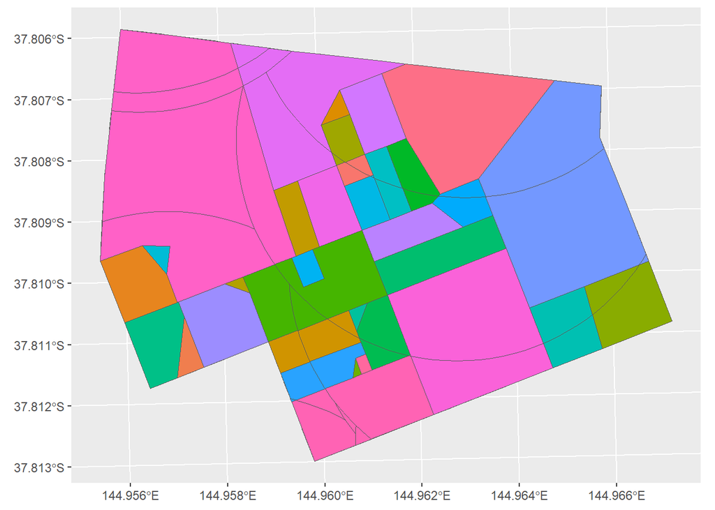

Catchment of each stop within each area of interest, Melbourne CBD - North SA1 zones, trams, by stop, first six stops

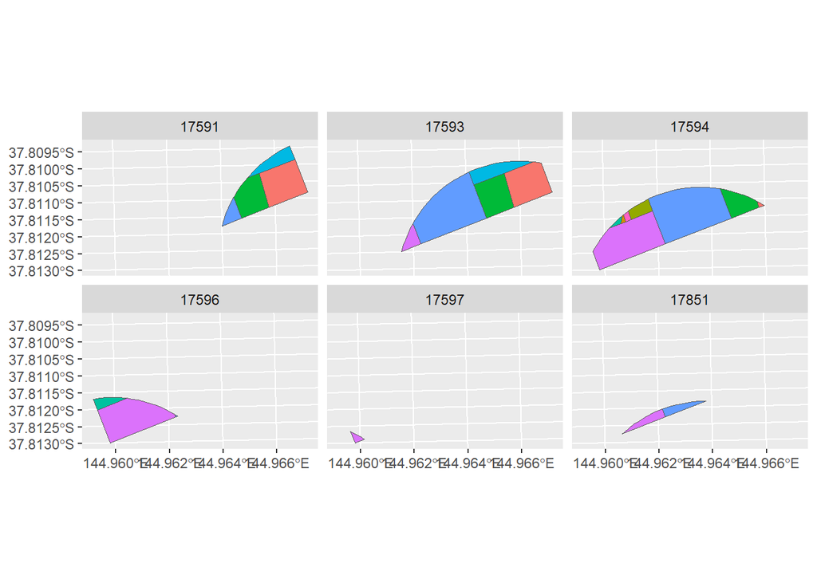

In general, the results appear to meet expectations. The first stop has a stop id of 17591. This stop is located at Russell and Bourke Street. A 400 metres catchment overlaid on this stop is shown in the margin. This matches the code output shown above (top left of figure).

https://transitfeeds.com/p/ptv/497/latest/stops?q=17591

Note: Roughly drawn from the ABS maps.

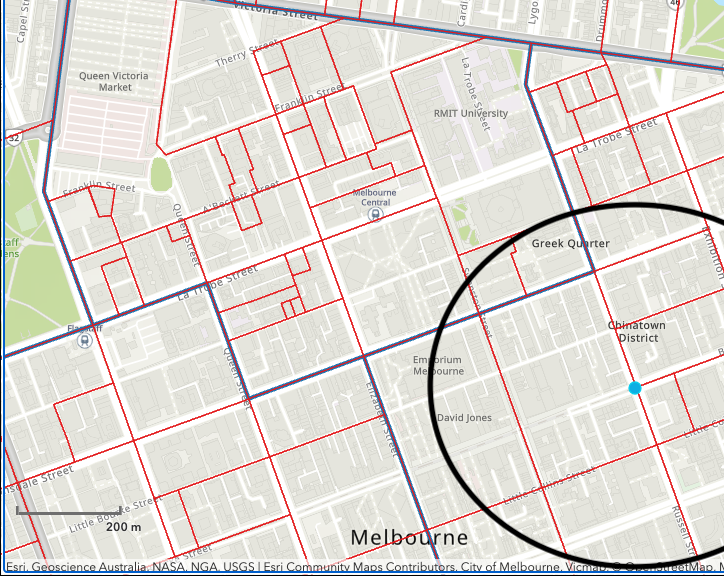

SA1 zone boundaries within the Melbourne CBD - North SA2, overlayed with 400m radius from Russell and Bourke Street. Source: ABS and author

Running the hourly function for January 16, 2024 gives the following output:

Victorian Trams and SA1 zones within the Melbourne CBD - North SA2 zone, hourly SI values for January 16, 2024, first 6 SA1 zones, zeroed columns excluded.

| area_id | 5:00 | 6:00 | 7:00 | 8:00 | 9:00 | 10:00 | 11:00 | 12:00 | 13:00 | 14:00 | 15:00 | 16:00 | 17:00 | 18:00 | 19:00 | 20:00 | 21:00 | 22:00 | 23:00 | 24:00 | 25:00 |
| --- | --- | --- | --- | --- | --- | --- | --- | --- | --- | --- | --- | --- | --- | --- | --- | --- | --- | --- | --- | --- | --- |
| 20604150401 | 38 | 244 | 354 | 434 | 400 | 367 | 351 | 352 | 363 | 361 | 369 | 411 | 432 | 362 | 279 | 222 | 189 | 164 | 166 | 69 | 2 |
| 20604150402 | 8 | 59 | 84 | 106 | 110 | 110 | 103 | 103 | 104 | 104 | 107 | 117 | 107 | 95 | 74 | 56 | 48 | 40 | 42 | 15 | 1 |
| 20604150403 | 8 | 41 | 57 | 70 | 70 | 74 | 68 | 66 | 68 | 67 | 73 | 78 | 66 | 64 | 52 | 43 | 35 | 29 | 30 | 13 | 2 |
| 20604150404 | 27 | 185 | 267 | 331 | 304 | 280 | 266 | 267 | 276 | 273 | 281 | 313 | 331 | 278 | 215 | 171 | 143 | 125 | 125 | 55 | 2 |
| 20604150405 | 20 | 129 | 186 | 231 | 222 | 208 | 198 | 199 | 202 | 201 | 205 | 231 | 230 | 197 | 153 | 117 | 100 | 84 | 88 | 37 | 2 |
| 20604150406 | 29 | 176 | 252 | 312 | 293 | 270 | 258 | 259 | 266 | 263 | 272 | 304 | 312 | 263 | 205 | 158 | 130 | 115 | 117 | 49 | 2 |

The below figure maps this output.

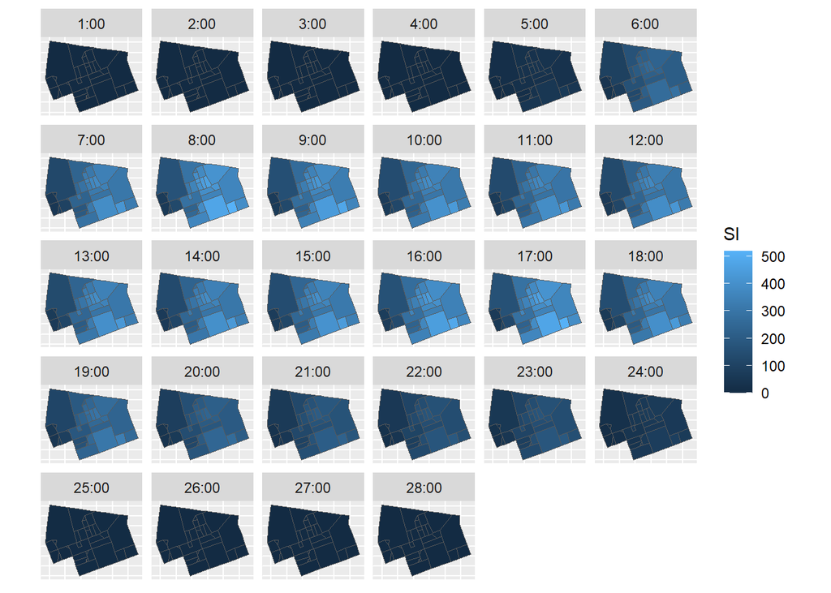

Victorian Trams and SA1 zones within the Melbourne CBD - North SA2 zone,SI values for January 16, 2024, by hour

In general, the results match expectations, with higher SI scores for SA1 zones that area closer to the Swanston, Elizabeth and Latrobe St corridors (which are where the trams are!)

### Rail only

Looking next at the rail only, running the stops_in_walk_dist function with verbose = TRUE gives the following output

Catchment of each stop within each area of interest, Melbourne CBD - North SA1 zones, rail

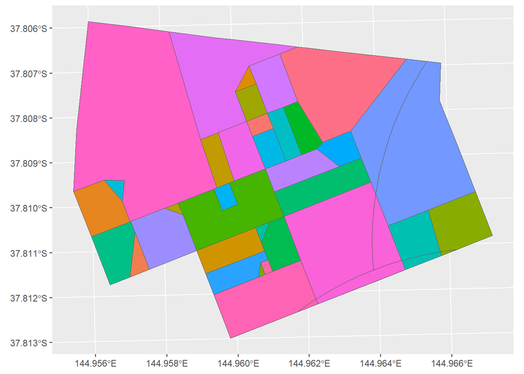

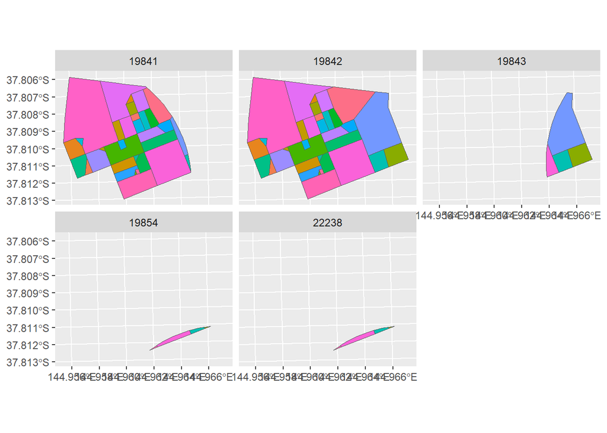

In general, the results appear to meet expectations:

- Flagstaff Railway Station (stop_id 19841) is roughly 800m from the intersection of Swanston Street and Lonsdale Street, which is where the arc shown in the bottom right of the top left figure terminates;

  https://transitfeeds.com/p/ptv/497/latest/stop/19841
- The entire SA2 is within the 800m catchment of Melbourne Central Station (stop_id 19842);
- Only a small part of the SA2 is within 800m of Parliament Station (to the south east, stop_id 19843).
- Only a small part of the SA2 is within 800m of Flinders Street Station (to the south, stop_ids 19854 and 22238). There are two stops related to Flinders Street because there are both Vline and Metro Trains services, which each have a different stop_id.

  https://transitfeeds.com/p/ptv/497/latest/stop/19854 and https://transitfeeds.com/p/ptv/497/latest/stop/22238

Running the hourly function for January 16, 2024 gives the following output:

| area_id | 5:00 | 6:00 | 7:00 | 8:00 | 9:00 | 10:00 | 11:00 | 12:00 | 13:00 | 14:00 | 15:00 | 16:00 | 17:00 | 18:00 | 19:00 | 20:00 | 21:00 | 22:00 | 23:00 | 24:00 | 25:00 |
| --- | --- | --- | --- | --- | --- | --- | --- | --- | --- | --- | --- | --- | --- | --- | --- | --- | --- | --- | --- | --- | --- |
| 20604150401 | 83 | 133 | 225 | 264 | 207 | 108 | 101 | 88 | 98 | 114 | 162 | 190 | 214 | 171 | 93 | 68 | 56 | 40 | 38 | 20 | 0 |
| 20604150402 | 83 | 133 | 225 | 264 | 207 | 108 | 101 | 88 | 98 | 114 | 162 | 190 | 214 | 171 | 93 | 68 | 56 | 40 | 38 | 20 | 0 |
| 20604150403 | 83 | 133 | 225 | 264 | 207 | 108 | 101 | 88 | 98 | 114 | 162 | 190 | 214 | 171 | 93 | 68 | 56 | 40 | 38 | 20 | 0 |
| 20604150404 | 83 | 133 | 225 | 264 | 207 | 108 | 101 | 88 | 98 | 114 | 162 | 190 | 214 | 171 | 93 | 68 | 56 | 40 | 38 | 20 | 0 |
| 20604150405 | 83 | 133 | 225 | 264 | 207 | 108 | 101 | 88 | 98 | 114 | 162 | 190 | 214 | 171 | 93 | 68 | 56 | 40 | 38 | 20 | 0 |
| 20604150406 | 83 | 133 | 225 | 264 | 207 | 108 | 101 | 88 | 98 | 114 | 162 | 190 | 214 | 171 | 93 | 68 | 56 | 40 | 38 | 20 | 0 |
| 20604150407 | 83 | 133 | 225 | 264 | 207 | 108 | 101 | 88 | 98 | 114 | 162 | 190 | 214 | 171 | 93 | 68 | 56 | 40 | 38 | 20 | 0 |
| 20604150408 | 83 | 133 | 225 | 264 | 207 | 108 | 101 | 88 | 98 | 114 | 162 | 190 | 214 | 171 | 93 | 68 | 56 | 40 | 38 | 20 | 0 |
| 20604150409 | 87 | 126 | 219 | 257 | 199 | 106 | 97 | 85 | 94 | 108 | 151 | 181 | 202 | 162 | 90 | 63 | 53 | 39 | 36 | 18 | 0 |
| 20604150410 | 83 | 133 | 225 | 264 | 207 | 108 | 101 | 88 | 98 | 114 | 162 | 190 | 214 | 171 | 93 | 68 | 56 | 40 | 38 | 20 | 0 |
| 20604150411 | 83 | 133 | 225 | 264 | 207 | 108 | 101 | 88 | 98 | 114 | 162 | 190 | 214 | 171 | 93 | 68 | 56 | 40 | 38 | 20 | 0 |
| 20604150412 | 83 | 133 | 225 | 264 | 207 | 108 | 101 | 88 | 98 | 114 | 162 | 190 | 214 | 171 | 93 | 68 | 56 | 40 | 38 | 20 | 0 |
| 20604150413 | 83 | 133 | 225 | 264 | 207 | 108 | 101 | 88 | 98 | 114 | 162 | 190 | 214 | 171 | 93 | 68 | 56 | 40 | 38 | 20 | 0 |
| 20604150414 | 83 | 133 | 225 | 264 | 207 | 108 | 101 | 88 | 98 | 114 | 162 | 190 | 214 | 171 | 93 | 68 | 56 | 40 | 38 | 20 | 0 |
| 20604150415 | 83 | 133 | 225 | 264 | 207 | 108 | 101 | 88 | 98 | 114 | 162 | 190 | 214 | 171 | 93 | 68 | 56 | 40 | 38 | 20 | 0 |
| 20604150416 | 83 | 133 | 225 | 264 | 207 | 108 | 101 | 88 | 98 | 114 | 162 | 190 | 214 | 171 | 93 | 68 | 56 | 40 | 38 | 20 | 0 |
| 20604150417 | 98 | 146 | 252 | 298 | 230 | 125 | 114 | 102 | 110 | 125 | 173 | 208 | 232 | 188 | 107 | 75 | 62 | 47 | 44 | 22 | 0 |
| 20604150418 | 83 | 133 | 225 | 264 | 207 | 108 | 101 | 88 | 98 | 114 | 162 | 190 | 214 | 171 | 93 | 68 | 56 | 40 | 38 | 20 | 0 |
| 20604150419 | 83 | 133 | 225 | 264 | 207 | 108 | 101 | 88 | 98 | 114 | 162 | 190 | 214 | 171 | 93 | 68 | 56 | 40 | 38 | 20 | 0 |
| 20604150420 | 83 | 133 | 225 | 264 | 207 | 108 | 101 | 88 | 98 | 114 | 162 | 190 | 214 | 171 | 93 | 68 | 56 | 40 | 38 | 20 | 0 |
| 20604150421 | 83 | 133 | 225 | 264 | 207 | 108 | 101 | 88 | 98 | 114 | 162 | 190 | 214 | 171 | 93 | 68 | 56 | 40 | 38 | 20 | 0 |
| 20604150422 | 83 | 133 | 225 | 264 | 207 | 108 | 101 | 88 | 98 | 114 | 162 | 190 | 214 | 171 | 93 | 68 | 56 | 40 | 38 | 20 | 0 |
| 20604150423 | 83 | 133 | 225 | 264 | 207 | 108 | 101 | 88 | 98 | 114 | 162 | 190 | 214 | 171 | 93 | 68 | 56 | 40 | 38 | 20 | 0 |
| 20604150424 | 79 | 116 | 201 | 236 | 183 | 97 | 89 | 78 | 86 | 99 | 139 | 166 | 186 | 149 | 82 | 58 | 48 | 35 | 33 | 17 | 0 |
| 20604150425 | 83 | 133 | 225 | 264 | 207 | 108 | 101 | 88 | 98 | 114 | 162 | 190 | 214 | 171 | 93 | 68 | 56 | 40 | 38 | 20 | 0 |
| 20604150426 | 83 | 133 | 225 | 264 | 207 | 108 | 101 | 88 | 98 | 114 | 162 | 190 | 214 | 171 | 93 | 68 | 56 | 40 | 38 | 20 | 0 |
| 20604150427 | 83 | 133 | 225 | 264 | 207 | 108 | 101 | 88 | 98 | 114 | 162 | 190 | 214 | 171 | 93 | 68 | 56 | 40 | 38 | 20 | 0 |
| 20604150428 | 83 | 133 | 225 | 264 | 207 | 108 | 101 | 88 | 98 | 114 | 162 | 190 | 214 | 171 | 93 | 68 | 56 | 40 | 38 | 20 | 0 |
| 20604150429 | 83 | 133 | 225 | 264 | 207 | 108 | 101 | 88 | 98 | 114 | 162 | 190 | 214 | 171 | 93 | 68 | 56 | 40 | 38 | 20 | 0 |
| 20604150430 | 95 | 152 | 257 | 303 | 236 | 126 | 117 | 103 | 113 | 130 | 183 | 216 | 243 | 195 | 108 | 79 | 65 | 47 | 45 | 23 | 0 |
| 20604150431 | 83 | 133 | 225 | 264 | 207 | 108 | 101 | 88 | 98 | 114 | 162 | 190 | 214 | 171 | 93 | 68 | 56 | 40 | 38 | 20 | 0 |
| 20604150432 | 84 | 134 | 227 | 266 | 209 | 109 | 102 | 89 | 99 | 115 | 163 | 191 | 216 | 172 | 94 | 69 | 57 | 41 | 38 | 20 | 0 |
| 20604150433 | 83 | 133 | 225 | 264 | 207 | 108 | 101 | 88 | 98 | 114 | 162 | 190 | 214 | 171 | 93 | 68 | 56 | 40 | 38 | 20 | 0 |
| 20604150434 | 63 | 97 | 167 | 194 | 153 | 80 | 75 | 65 | 71 | 82 | 115 | 136 | 154 | 122 | 67 | 49 | 40 | 29 | 27 | 14 | 0 |

This appears to meet expectations, with SI scores peaking in the morning (8-9) and evening (17-18). A lot of the SA1 zones have identical SI scores because ALL of their area is within the 800m buffer distance of a railway station, meaning that the area terms cancel out and are equal to one.

The below figure maps this output.

[figure not shown]

Victorian rail and SA1 zones within the Melbourne CBD - North SA2 zone,SI values for January 16, 2024, by hour

### Full SI calculation

This section runs the SI calculation for all modes (lrt, rail, bus) on SA1 zones within the Melbourne CBD - North SA2 zone. Here verbose is set as FALSE to cut down on the amount of output displayed.

| area_id | 2:00 | 3:00 | 4:00 | 5:00 | 6:00 | 7:00 | 8:00 | 9:00 | 10:00 | 11:00 | 12:00 | 13:00 | 14:00 | 15:00 | 16:00 | 17:00 | 18:00 | 19:00 | 20:00 | 21:00 | 22:00 |
| --- | --- | --- | --- | --- | --- | --- | --- | --- | --- | --- | --- | --- | --- | --- | --- | --- | --- | --- | --- | --- | --- |
| 20604150401 | 0 | 0 | 2 | 123 | 389 | 603 | 729 | 636 | 498 | 474 | 463 | 484 | 498 | 554 | 627 | 673 | 558 | 396 | 307 | 258 | 214 |
| 20604150402 | 0 | 0 | 2 | 122 | 312 | 542 | 711 | 623 | 425 | 393 | 382 | 393 | 413 | 474 | 559 | 610 | 503 | 366 | 286 | 229 | 177 |
| 20604150403 | 0 | 0 | 2 | 96 | 216 | 361 | 435 | 375 | 256 | 241 | 227 | 238 | 254 | 309 | 357 | 377 | 319 | 221 | 170 | 138 | 108 |
| 20604150404 | 0 | 0 | 2 | 111 | 328 | 510 | 618 | 532 | 406 | 383 | 373 | 391 | 405 | 460 | 522 | 566 | 467 | 326 | 252 | 208 | 173 |
| 20604150405 | 0 | 0 | 2 | 138 | 395 | 672 | 855 | 749 | 543 | 506 | 496 | 511 | 533 | 599 | 700 | 763 | 634 | 452 | 356 | 287 | 224 |
| 20604150406 | 0 | 0 | 2 | 118 | 351 | 556 | 677 | 597 | 451 | 430 | 418 | 435 | 450 | 508 | 583 | 624 | 519 | 369 | 282 | 230 | 190 |
| 20604150407 | 0 | 0 | 2 | 125 | 326 | 536 | 669 | 591 | 421 | 400 | 388 | 401 | 420 | 485 | 576 | 631 | 511 | 364 | 278 | 224 | 176 |
| 20604150408 | 0 | 0 | 2 | 118 | 369 | 572 | 687 | 598 | 464 | 441 | 430 | 449 | 463 | 519 | 588 | 636 | 525 | 370 | 287 | 239 | 199 |
| 20604150409 | 0 | 0 | 4 | 164 | 426 | 715 | 886 | 752 | 575 | 542 | 527 | 548 | 572 | 630 | 729 | 806 | 660 | 466 | 374 | 309 | 246 |
| 20604150410 | 0 | 0 | 3 | 167 | 475 | 803 | 1034 | 905 | 664 | 624 | 608 | 631 | 653 | 725 | 852 | 941 | 777 | 547 | 431 | 350 | 274 |
| 20604150411 | 0 | 0 | 2 | 135 | 397 | 657 | 830 | 725 | 533 | 500 | 490 | 507 | 527 | 590 | 685 | 745 | 617 | 440 | 346 | 281 | 224 |
| 20604150412 | 0 | 0 | 2 | 129 | 422 | 654 | 784 | 686 | 542 | 517 | 506 | 529 | 544 | 600 | 683 | 733 | 606 | 429 | 337 | 285 | 235 |
| 20604150413 | 0 | 0 | 2 | 161 | 494 | 829 | 1056 | 914 | 683 | 641 | 628 | 652 | 673 | 744 | 866 | 958 | 789 | 563 | 450 | 364 | 288 |
| 20604150414 | 0 | 0 | 2 | 143 | 432 | 712 | 885 | 760 | 573 | 541 | 527 | 552 | 571 | 634 | 738 | 808 | 661 | 464 | 373 | 304 | 243 |
| 20604150415 | 0 | 0 | 2 | 114 | 272 | 474 | 624 | 541 | 355 | 328 | 316 | 327 | 345 | 403 | 473 | 513 | 427 | 311 | 245 | 195 | 150 |
| 20604150416 | 0 | 0 | 2 | 149 | 462 | 775 | 993 | 852 | 632 | 589 | 577 | 600 | 619 | 684 | 797 | 872 | 725 | 518 | 417 | 338 | 268 |
| 20604150417 | 0 | 0 | 5 | 191 | 518 | 862 | 1103 | 938 | 711 | 668 | 653 | 675 | 696 | 760 | 868 | 947 | 793 | 569 | 450 | 372 | 298 |
| 20604150418 | 0 | 0 | 2 | 127 | 408 | 634 | 765 | 668 | 525 | 500 | 490 | 511 | 527 | 582 | 659 | 705 | 587 | 416 | 325 | 275 | 227 |
| 20604150419 | 0 | 0 | 2 | 94 | 207 | 342 | 411 | 351 | 238 | 225 | 211 | 222 | 238 | 290 | 333 | 350 | 299 | 204 | 155 | 126 | 99 |
| 20604150420 | 0 | 0 | 2 | 124 | 388 | 609 | 745 | 649 | 502 | 478 | 467 | 487 | 502 | 558 | 634 | 678 | 566 | 401 | 310 | 261 | 214 |
| 20604150421 | 0 | 0 | 2 | 137 | 429 | 696 | 877 | 773 | 578 | 545 | 534 | 552 | 571 | 631 | 725 | 782 | 654 | 473 | 370 | 301 | 245 |
| 20604150422 | 0 | 0 | 2 | 140 | 431 | 688 | 842 | 723 | 558 | 531 | 516 | 543 | 559 | 617 | 715 | 777 | 636 | 444 | 355 | 297 | 241 |
| 20604150423 | 0 | 0 | 3 | 151 | 422 | 720 | 922 | 811 | 589 | 550 | 538 | 555 | 578 | 646 | 752 | 821 | 686 | 488 | 382 | 309 | 241 |
| 20604150424 | 0 | 0 | 2 | 133 | 393 | 643 | 774 | 661 | 518 | 488 | 475 | 497 | 513 | 562 | 649 | 703 | 580 | 410 | 334 | 278 | 224 |
| 20604150425 | 0 | 0 | 2 | 125 | 320 | 549 | 712 | 618 | 427 | 397 | 387 | 398 | 418 | 481 | 568 | 623 | 512 | 367 | 287 | 229 | 177 |
| 20604150426 | 0 | 0 | 2 | 142 | 440 | 716 | 893 | 773 | 588 | 555 | 543 | 567 | 586 | 647 | 749 | 814 | 671 | 474 | 375 | 308 | 248 |
| 20604150427 | 0 | 0 | 2 | 117 | 355 | 553 | 659 | 571 | 440 | 418 | 407 | 427 | 441 | 496 | 563 | 610 | 503 | 350 | 274 | 229 | 190 |
| 20604150428 | 0 | 0 | 3 | 113 | 309 | 478 | 581 | 496 | 370 | 349 | 336 | 354 | 367 | 426 | 483 | 524 | 437 | 305 | 234 | 191 | 158 |
| 20604150429 | 0 | 0 | 2 | 121 | 370 | 584 | 709 | 624 | 477 | 455 | 444 | 462 | 477 | 533 | 610 | 654 | 543 | 387 | 296 | 246 | 203 |
| 20604150430 | 0 | 0 | 3 | 179 | 533 | 874 | 1094 | 946 | 720 | 680 | 665 | 691 | 714 | 788 | 910 | 1004 | 825 | 585 | 468 | 383 | 306 |
| 20604150431 | 0 | 0 | 3 | 105 | 251 | 395 | 488 | 420 | 295 | 277 | 264 | 277 | 292 | 348 | 402 | 430 | 365 | 252 | 186 | 151 | 121 |
| 20604150432 | 0 | 0 | 4 | 180 | 506 | 854 | 1098 | 963 | 716 | 672 | 658 | 679 | 702 | 778 | 903 | 996 | 827 | 593 | 465 | 379 | 296 |
| 20604150433 | 0 | 0 | 3 | 168 | 480 | 814 | 1040 | 912 | 671 | 632 | 616 | 639 | 661 | 738 | 866 | 963 | 791 | 560 | 441 | 356 | 278 |
| 20604150434 | 0 | 0 | 1 | 104 | 355 | 548 | 644 | 565 | 459 | 438 | 428 | 447 | 457 | 497 | 566 | 608 | 502 | 357 | 286 | 244 | 203 |

This appears to meet expectations, with SI scores peaking in the morning (8-9) and evening (17-18).

The below figure maps this output.

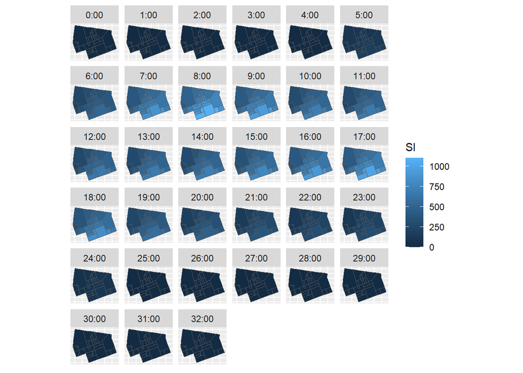

[output not shown]